# PA1_template

## Coursera: Reproducible Research Assignment 1

### Preparation for the Assignment

The packages used are:

```r
library(dplyr)
```

```r
library(ggplot2)
```

Reading in the data and processing it

```r
activity <- read.csv("activity.csv")
str(activity)
```

```
## 'data.frame':    17568 obs. of  3 variables:
##  $ steps   : int  NA NA NA NA NA NA NA NA NA NA ...
##  $ date    : chr  "2012-10-01" "2012-10-01" "2012-10-01" "2012-10-01" ...
##  $ interval: int  0 5 10 15 20 25 30 35 40 45 ...
```

```r
activity$date <- as.POSIXct(activity$date, format = "%Y- %m -%d")
activity$steps <- as.double(activity$steps)
head(activity)
```

```
##   steps       date interval
## 1    NA 2012-10-01        0
## 2    NA 2012-10-01        5
## 3    NA 2012-10-01       10
## 4    NA 2012-10-01       15
## 5    NA 2012-10-01       20
## 6    NA 2012-10-01       25
```

We transformed the steps to double due to replacing the missing values by their mean later on.

### Task1: What is mean total number of steps taken per day?

Preparing the data and use `na.rm = TRUE` to ignore missing values.

```r
task1 <- activity %>%
    group_by(date) %>%
    summarise(steps = sum(steps, na.rm = TRUE))
head(task1)
```

```
## # A tibble: 6 x 2
##   date                steps
##   <dttm>              <dbl>
## 1 2012-10-01 00:00:00     0
## 2 2012-10-02 00:00:00   126
## 3 2012-10-03 00:00:00 11352
## 4 2012-10-04 00:00:00 12116
## 5 2012-10-05 00:00:00 13294
## 6 2012-10-06 00:00:00 15420
```

Make the plot with base R:

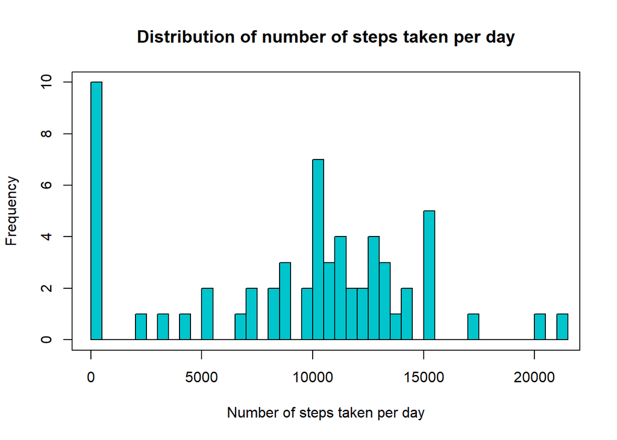

```r
hist(
    task1$steps,
    xlab = "Number of steps taken per day",
    xlim = c(0, max(task1$steps)),
    breaks = nrow(task1),
    main = "Distribution of number of steps taken per day",
    col = "turquoise3"
)
box()
```

Calculate and save the mean and the median:

```r
mean_task1 <- mean(task1$steps)
mean_task1
```

```
## [1] 9354.23
```

```r
median_task1 <- median(task1$steps)
median_task1
```

```
## [1] 10395
```

### Task2: What is the average daily activity pattern?

Preparing the data for the time series plot:

```r
task2 <- activity %>%
    group_by(interval) %>%
    summarise(steps = mean(steps, na.rm = TRUE))
head(task2)
```

```
## # A tibble: 6 x 2
##   interval  steps
##      <int>  <dbl>
## 1        0 1.72
## 2        5 0.340
## 3       10 0.132
## 4       15 0.151
## 5       20 0.0755
## 6       25 2.09
```

Make the plot with ggplot2:

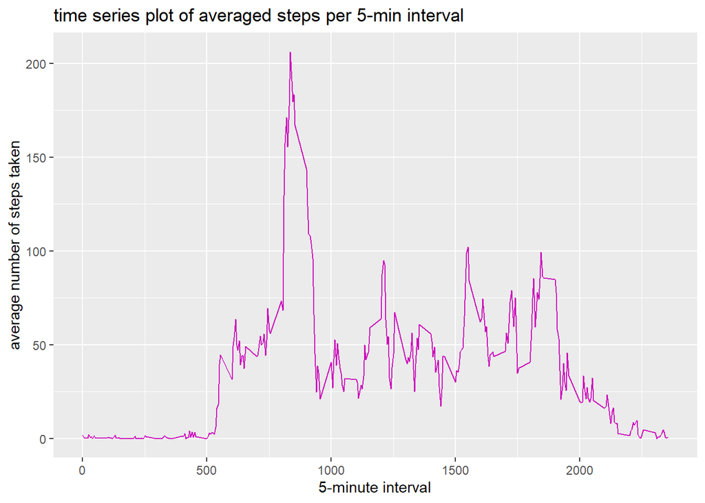

```r
ggplot(data = task2, aes(x = interval, y = steps)) +
    geom_line(color = 6, size = 0.5) +
    xlab("5-minute interval") +
    ylab("average number of steps taken")+
    labs(title = "time series plot of averaged steps per 5-min interval",
         color = "types")
```

```r
interval_max_steps <- which.max(task2$interval)
interval_max_steps
```

```
## [1] 288
```

### Task3: Imputing missing values

The number of rows with missing values can be calculated by

```r
na_rows <- nrow(activity %>% filter(is.na(steps)))
na_rows
```

```
## [1] 2304
```

The method we are going to use to impute the missing values is by replacing them by the mean of the corresponding 5-minute interval.

```r
activity_noan <-
    left_join(activity,
              task2 %>% rename(steps_mean = steps),
              by = c("interval" = "interval")) %>%
    mutate(steps = case_when(is.na(steps) ~ steps_mean, TRUE ~ steps)) %>%
    select(-steps_mean)
head(activity_noan)
```

```
##       steps       date interval
## 1 1.7169811 2012-10-01        0
## 2 0.3396226 2012-10-01        5
## 3 0.1320755 2012-10-01       10
## 4 0.1509434 2012-10-01       15
## 5 0.0754717 2012-10-01       20
## 6 2.0943396 2012-10-01       25
```

For the new histogram the data is processed

```r
task1_noan <- activity_noan %>%
    group_by(date) %>%
    summarise(steps = sum(steps, na.rm = TRUE))
head(task1_noan)
```

```
## # A tibble: 6 x 2
##   date                 steps
##   <dttm>               <dbl>
## 1 2012-10-01 00:00:00 10766.
## 2 2012-10-02 00:00:00   126
## 3 2012-10-03 00:00:00 11352
## 4 2012-10-04 00:00:00 12116
## 5 2012-10-05 00:00:00 13294
## 6 2012-10-06 00:00:00 15420
```

And then the plot is made by the code

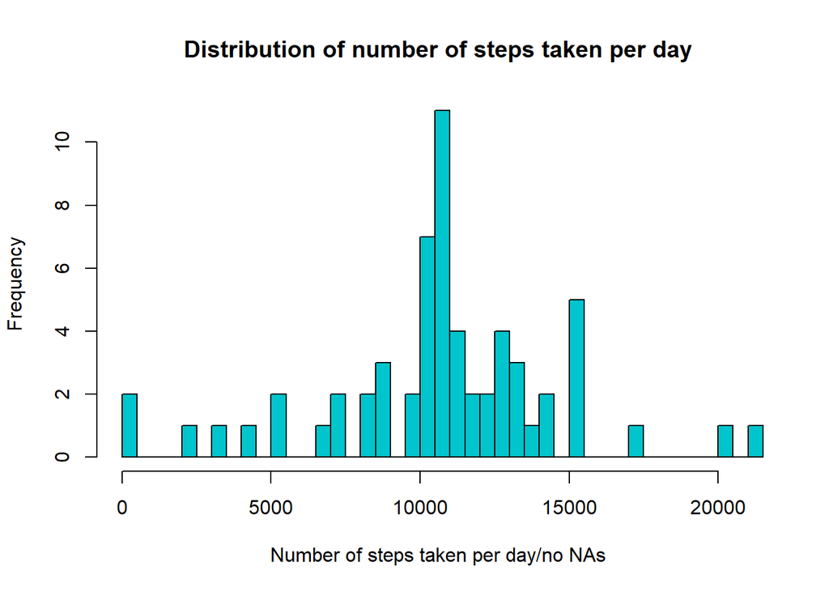

```r
hist(
    task1_noan$steps,
    xlab = "Number of steps taken per day/no NAs",
    xlim = c(0, max(task1_noan$steps)),
    breaks = nrow(task1_noan),
    main = "Distribution of number of steps taken per day",
    col = "turquoise3"
)
```

The new mean and median are

```r
mean_task1_noan <- mean(task1_noan$steps)
mean_task1_noan
```

```
## [1] 10766.19
```

```r
median_task1_noan <- median(task1_noan$steps)
median_task1_noan
```

```
## [1] 10766.19
```

### Task 4: Are there differences in activity patterns between weekdays and weekends?

We again prepare the data for the next analysis by adding a factor variable which tells us if a day was a weekday or not

```r
task4 <- activity_noan %>%
    mutate(dtype = as.factor(case_when(
        weekdays(date) %in% c("Samstag", "Sonntag") ~ "weekend",
        TRUE ~ "weekday"
    )))
head(task4)
```

```
##       steps       date interval   dtype
## 1 1.7169811 2012-10-01        0 weekday
## 2 0.3396226 2012-10-01        5 weekday
## 3 0.1320755 2012-10-01       10 weekday
## 4 0.1509434 2012-10-01       15 weekday
## 5 0.0754717 2012-10-01       20 weekday
## 6 2.0943396 2012-10-01       25 weekday
```

After adding the new variable we calculate the mean for each 5-minute interval and each daytype

```r
task4_plot <- task4 %>%
    group_by(dtype, interval) %>%
    summarise_at(vars(steps), funs(mean(.,na.rm =TRUE)))
head(task4_plot)
```

```
## # A tibble: 6 x 3
## # Groups:   dtype [1]
##   dtype   interval  steps
##   <fct>      <int>  <dbl>
## 1 weekday        0 2.25
## 2 weekday        5 0.445
## 3 weekday       10 0.173
## 4 weekday       15 0.198
## 5 weekday       20 0.0990
## 6 weekday       25 1.59
```

The result is

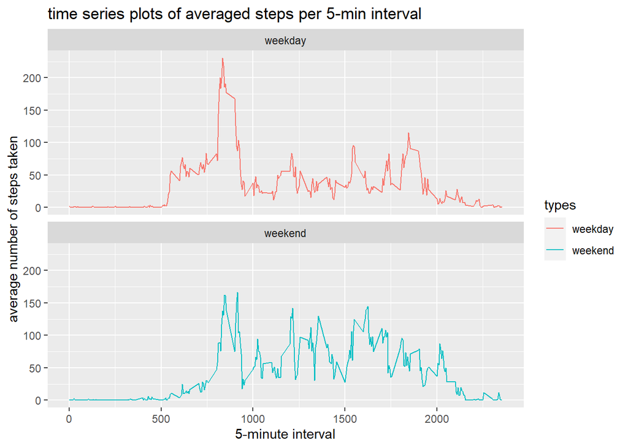

```r
ggplot(data = task4_plot, aes(x = interval, y = steps, color = dtype)) +
    geom_line(size = 0.5) +
    facet_wrap(~dtype ,ncol = 1, nrow = 2)+
    xlab("5-minute interval") +
    ylab("average number of steps taken")+
    labs(title = "time series plots of averaged steps per 5-min interval",
         color = "types")
```